# scFlow Workshop

Worksheet: Navigating the SingleCellExperiment Object

Author

Combiz Khozoie, Ph.D.

Published

August 5, 2022

## Background

The SingleCellExperiment (SCE) object stores data for single-cell/nuclei experiments. This [Bioconductor S4 class](https://bioconductor.org/packages/release/bioc/html/SingleCellExperiment.html) provides methods for synchronised storage and retrieval of data including gene counts/expression, transformed matrices, cellular metrics, sample metadata, and dimensionality reduction data.

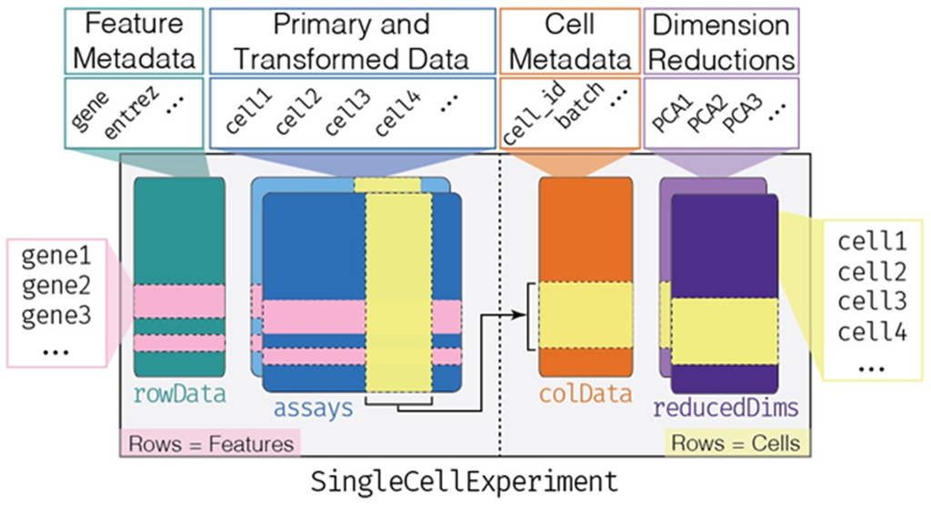

In this lesson, we’ll learn how to navigate a SingleCellExperiment object, retrieve, append, and modify different data types, and perform other useful tasks including subsetting.

## Getting Started

You should already have a SingleCellExperiment object named ‘sce’ in your environment. If not, load one now, e.g.

```r
library(scFlow)
sce_path <- "~/Documents/scFlow_Resources/MS_Example_Final"
sce <- read_sce(sce_path)
```

Typing the name of the *sce* object will display information about the data stored.

```r
sce
```

```
class: SingleCellExperiment
dim: 19739 22073
metadata(0):
assays(1): counts
rownames(19739): ENSG00000000003 ENSG00000000419 ... ENSG00000283117
  ENSG00000283118
rowData names(6): ensembl_gene_id gene_biotype ... total_counts
  n_cells_by_counts
colnames(22073): MS530_Low_AAACCTGTCTCGTATT-1
  MS530_Low_AAACGGGTCTGATTCT-1 ... MS527_High_TTTGGTTTCGTCCAGG-1
  MS527_High_TTTGTCATCCTTTCGG-1
colData names(37): barcode individual ... partitions cluster_celltype
reducedDimNames(6): Liger PCA ... UMAP3D_Liger UMAP3D_PCA
mainExpName: NULL
altExpNames(0):
```

You can retrieve the number of genes (rows) and cells (columns) using the base R function `dim()` on the SingleCellExperiment object. Let’s try this now.

```r
dim(sce)
```

```
[1] 19739 22073
```

```r
dim(sce)[1] # the number of genes
```

```
[1] 19739
```

```r
dim(sce)[2] # the number of cells
```

```
[1] 22073
```

## Retrieving Data

The first data type we may need to access are assays. These typically include the raw gene expression/counts matrix, but can also include transformations of the matrix (e.g. CPM).

The **SummarizedExperiment** package includes the `assayNames()` function that lists the assays attached to the *sce*. Let’s try this now.

```r
SummarizedExperiment::assayNames(sce)
```

```
[1] "counts"
```

We should see the raw *counts* matrix. There are several alternative functions available to access a specific assay. Here, we will access the assay by name with the `SummarizedExperiment::assay()` function, which takes the *sce* object as its first parameter and the assay name as its second parameter.

```r
SummarizedExperiment::assay(sce, "counts")
```

You may have noticed that the matrix class is **dgTMatrix**.

```r
class(SummarizedExperiment::assay(sce, "counts"))
```

```
[1] "dgTMatrix"
attr(,"package")
[1] "Matrix"
```

Tip: This is a type of sparse matrix. We can interact with this matrix in the same way as a normal (dense) matrix, but under the hood it uses a triplet format (x, y, value) to store only non-zero data points; this is a memory efficient way of storing sparse data. It’s useful to be aware of the difference and to use sparse matrices for sparse counts data, rather than the default dense matrix, otherwise you may run out of RAM and storage space!

### Accessing column data (cell-level data)

The second data type we will look at is column data. The columns in a SingleCellExperiment assay are cells, so the column data stores data related to cells, including both sample-level (e.g. age, disease status) and cell-level (e.g. total counts, total genes) metrics.

We can access the column data using the `SummarizedExperiment::colData()` function on the *sce*. Let’s try this now.

```r
SummarizedExperiment::colData(sce)
```

The output is a *DFrame* object, akin to a standard R *data.frame* object.

```r
class(SummarizedExperiment::colData(sce))
```

```
[1] "DFrame"
attr(,"package")
[1] "S4Vectors"
```

You can even use standard R *data.frame* syntax to retrieve and assign data to the column data by referencing only the sce object, e.g. `sce$total_counts`. Try this now.

```r
median(sce$total_counts)
```

```
[1] 1927
```

```r
table(sce$cluster_celltype)
```

```
   Astro  EN-L2-3  EN-L3-5  EN-L4-6  EN-L5-6     Endo IN-PVALB   IN-SST
    3464     3389     1540      677     1227      462     1379      895
  IN-VIP    Micro    Oligo      OPC      PVM
    1008     1228     4970     1685      149
```

The full list of column data variables can be retrieved in a similar way.

```r
colnames(SummarizedExperiment::colData(sce))
```

```
 [1] "barcode"                  "individual"
 [3] "group"                    "diagnosis"
 [5] "coverage"                 "sex"
 [7] "age"                      "PMI"
 [9] "duration"                 "capdate"
[11] "prepdate"                 "seqdate"
[13] "nucleicount"              "cdnaconc"
[15] "libraryconc"              "MLS"
[17] "RIN"                      "ap"
[19] "aplevel"                  "manifest"
[21] "total_counts"             "total_features_by_counts"
[23] "pc_mito"                  "pc_ribo"
[25] "Neun_all"                 "NeunII_III"
[27] "NeunV_VI"                 "Demyelination"
[29] "HLA_LI"                   "HLA_LII_III"
[31] "HLA_LV_VI"                "HLA_all"
[33] "Mening_CD20"              "Mening_CD3"
[35] "clusters"                 "partitions"
[37] "cluster_celltype"
```

### Accessing row data (gene-level data)

Similarly to colData, we can also access and assign row (gene) level data using the `SummarizedExperiment::rowData()` function. Try this now.

```r
SummarizedExperiment::rowData(sce)
```

And we can similarly list the row data variables.

```r
colnames(SummarizedExperiment::rowData(sce))
```

```
[1] "ensembl_gene_id"            "gene_biotype"
[3] "gene"                       "percentage_gene_gc_content"
[5] "total_counts"               "n_cells_by_counts"
```

Unlike accessing colData variables, we need to use the `rowData()` function to access individual row data variables. Try this now to retrieve the *gene* variable from the row data.

```r
head(SummarizedExperiment::rowData(sce)$gene)
```

```
[1] "TSPAN6"   "DPM1"     "SCYL3"    "C1orf112" "FGR"      "CFH"
```

### Accessing dimensionality reduction data

The third data type we may need to access are the dimensionality reduction matrices. We can list these with the `reducedDimNames()` function from the `SingleCellExperiment` package.

```r
SingleCellExperiment::reducedDimNames(sce)
```

```
[1] "Liger"        "PCA"          "UMAP_Liger"   "UMAP_PCA"     "UMAP3D_Liger"
[6] "UMAP3D_PCA"
```

We can access and assign reduced dimension matrices from/to a *sce* using the `SingleCellExperiment::reducedDim()` function. Try this now to retrieve the **PCA** embeddings.

```r
head(SingleCellExperiment::reducedDim(sce, "PCA"))
```

```
                                    PC1        PC2       PC3        PC4
MS530_Low_AAACCTGTCTCGTATT-1 -13.660180 -17.855042  1.867519  -9.031712
MS530_Low_AAACGGGTCTGATTCT-1 -15.472018 -14.941556 -1.149674  -8.835576
MS530_Low_AAAGCAACACGTGAGA-1  -5.300054  -3.046584 -7.577899 -16.853343
MS530_Low_AACACGTAGCCCTAAT-1 -18.494904   3.947897 -3.178889  -9.133942
MS530_Low_AACCATGGTAGTAGTA-1  -2.948766  -3.847140 -7.563956 -12.726794
MS530_Low_AACGTTGCAACTGGCC-1 -13.294633 -20.303198  3.712729  -7.444442
                                     PC5        PC6         PC7        PC8
MS530_Low_AAACCTGTCTCGTATT-1  -5.0106174  -7.507910  1.33605312 -1.0849034
MS530_Low_AAACGGGTCTGATTCT-1  -8.0902972  -8.259528  0.77715069  0.9946511
MS530_Low_AAAGCAACACGTGAGA-1 -13.4022333 -12.777187 -0.28615912  1.2686384
MS530_Low_AACACGTAGCCCTAAT-1  -7.0235993  -9.387055 -0.04173504  2.2069584
MS530_Low_AACCATGGTAGTAGTA-1 -14.7797817  -8.260180  1.14614204 -0.5677160
MS530_Low_AACGTTGCAACTGGCC-1   0.3961717  -4.601133  2.00874367 -2.4795737
                                   PC9       PC10        PC11       PC12
MS530_Low_AAACCTGTCTCGTATT-1 -4.941365 -4.0781689 -1.50863576 -1.8774245
MS530_Low_AAACGGGTCTGATTCT-1 -7.212958 -5.1407428 -0.42266347 -2.2040782
MS530_Low_AAAGCAACACGTGAGA-1 -7.176946 -2.3393324 -0.79498120  1.5239325
MS530_Low_AACACGTAGCCCTAAT-1 -4.895295 -2.0154308  0.23226123 -0.7136159
MS530_Low_AACCATGGTAGTAGTA-1 -8.387862 -8.2076396  0.04075785 -0.8294228
MS530_Low_AACGTTGCAACTGGCC-1 -1.085164 -0.9550573 -0.23441074  1.3251242
                                 PC13       PC14       PC15        PC16
MS530_Low_AAACCTGTCTCGTATT-1 1.708170 -0.7282208 -2.1825093  0.42322511
MS530_Low_AAACGGGTCTGATTCT-1 2.745736 -0.2307923  1.1776789 -1.21953437
MS530_Low_AAAGCAACACGTGAGA-1 2.214713 -3.7446115  2.1494074 -0.40570694
MS530_Low_AACACGTAGCCCTAAT-1 1.685325 -1.0568387  0.8924458 -0.16448974
MS530_Low_AACCATGGTAGTAGTA-1 2.142717 -1.4911390  0.8491870 -0.01019357
MS530_Low_AACGTTGCAACTGGCC-1 1.278595 -0.3968191 -1.0092014  0.79136948
                                   PC17     PC18      PC19      PC20
MS530_Low_AAACCTGTCTCGTATT-1  1.6980495 4.063429 2.4840822 -5.677135
MS530_Low_AAACGGGTCTGATTCT-1 -0.5749477 1.928135 0.8594616 -2.120831
MS530_Low_AAAGCAACACGTGAGA-1 -7.1367247 4.945505 3.7535200  1.721788
MS530_Low_AACACGTAGCCCTAAT-1 -1.4020265 3.267303 1.3684702 -1.797847
MS530_Low_AACCATGGTAGTAGTA-1 -2.4392266 1.011107 1.9700080  1.043056
MS530_Low_AACGTTGCAACTGGCC-1  2.8346204 3.281742 0.5282428 -6.522531
```

### Accessing metadata

The final *sce* data type we will consider in this tutorial is the **metadata** slot. This is a list that can be accessed with `sce@metadata`. Many functions in scFlow attach nested analytical results and plots to this metadata list, so you may want to inspect it after running certain functions. That’s all for data types today!

## Subsetting the SingleCellExperiment object

The final part of this lesson concerns subsetting. We may want to subset the *sce* to focus on a particular cell-type or cluster, or perhaps for performance/testing reasons if we have a very large dataset.

We can subset a SingleCellExperiment using standard R syntax for subsetting rows/columns (e.g. `sce[genes_idx, cells_idx]`). The SingleCellExperiment class will automatically apply the subsetting across all of the relevant data types (e.g. assays, colData, rowData, and redDims).

### Subsetting by colData

We can use colData indexing to subset the cells, for example `sce[, sce$diagnosis == "Control"]` returns only control cells. Let’s try this now to subset only microglial cells.

```r
sce[, sce$cluster_celltype == "Micro"]
```

```
class: SingleCellExperiment
dim: 19739 1228
metadata(0):
assays(1): counts
rownames(19739): ENSG00000000003 ENSG00000000419 ... ENSG00000283117
  ENSG00000283118
rowData names(6): ensembl_gene_id gene_biotype ... total_counts
  n_cells_by_counts
colnames(1228): MS523_Low_AACTCTTCATCGATGT-1
  MS523_Low_AAGCCGCGTGGAAAGA-1 ... MS527_High_TTATGCTCAGACGCAA-1
  MS527_High_TTCGGTCAGGATTCGG-1
colData names(37): barcode individual ... partitions cluster_celltype
reducedDimNames(6): Liger PCA ... UMAP3D_Liger UMAP3D_PCA
mainExpName: NULL
altExpNames(0):
```

### Subsetting by rowData

Similarly, we can also subset rows (genes). We will need to access the rowData using the `SummarizedExperiment::rowData()` function as explored earlier.

Let’s combine both row (gene) and column (cell) subsetting to return a new *sce* object containing only protein coding genes and endothelial cells.

```r
endo_sce <- sce[SummarizedExperiment::rowData(sce)$gene_biotype == "protein_coding", sce$cluster_celltype == "Endo"]

endo_sce
```

```
class: SingleCellExperiment
dim: 15252 462
metadata(0):
assays(1): counts
rownames(15252): ENSG00000000003 ENSG00000000419 ... ENSG00000282988
  ENSG00000283071
rowData names(6): ensembl_gene_id gene_biotype ... total_counts
  n_cells_by_counts
colnames(462): MS530_Low_AAGCCGCAGAATGTGT-1
  MS530_Low_AGCATACGTTCAGTAC-1 ... MS527_High_TCTCTAAAGCGATTCT-1
  MS527_High_TGCGCAGGTTCACGGC-1
colData names(37): barcode individual ... partitions cluster_celltype
reducedDimNames(6): Liger PCA ... UMAP3D_Liger UMAP3D_PCA
mainExpName: NULL
altExpNames(0):
```

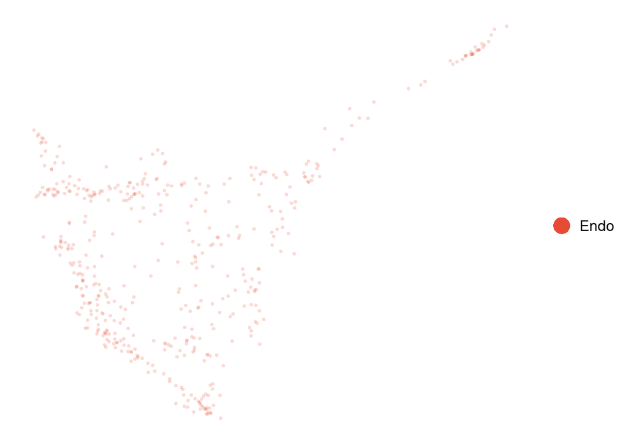

**Figure**: 2D UMAP embeddings for endothelial cells

```r
plot_reduced_dim(
    endo_sce,
    feature_dim = "cluster_celltype",
    reduced_dim = "UMAP_Liger",
    size = 1
)
```

## Summary

The subsetting and data retrieval/accessing functions we’ve covered here are the most commonly used for working with SingleCellExperiment objects. You can learn more about the SingleCellExperiment class in the manuscript [here](https://www.ncbi.nlm.nih.gov/pmc/articles/PMC7358058/) and the Bioconductor package documentation [here](https://bioconductor.org/packages/release/bioc/html/SingleCellExperiment.html).